# Meta-Analyses in Education: From Theory to Practice with R

Diego G. Campos and Ronny Scherer (University of Oslo)

TU Dortmund University, 20-21 February 2025

# Content

This material supplements the workshop held at [TU Dortmund University](https://ifs.ep.tu-dortmund.de/) on Meta-Analyses in Educational Research by [Diego G. Campos](https://www.uv.uio.no/cemo/english/people/aca/diegogc/) and [Ronny Scherer](https://www.uv.uio.no/cemo/english/people/aca/ronnysc/). You can copy, modify, distribute, or display this material for non-commercial and academic uses without permission and with referencing the authors.

This material contains the analytic code of an illustrative example, comments, and descriptions. The analyses include the estimation and selection of a meta-analytic baseline (working) model, moderator analyses, and the inspection of publication bias and influential effect sizes.

# Data Preparation

This illustrative example uses a meta-analytic data set published and presented by Campos et al. (2023), https://doi.org/10.1037/met0000539 and Scherer et al. (2024), https://doi.org/10.1186/s40536-024-00191-1.

## Install and load relevant `R` packages

```r
# Install R packages (if needed)
# install.packages("pacman")
library(pacman)
pacman::p_load(tidyverse, # for data wrangling
               metafor, # for meta-analytic working models
               clubSandwich, # for cluster-robust SE estimation
               robumeta, # for RVE
               readxl, # for reading Excel files
               optimParallel, # for using multiple processors
               devtools, # for installing some R packages via GitHub
               PublicationBias # for some publication bias analyses
               )

## Install dmetar
#devtools::install_github("MathiasHarrer/dmetar")
library(dmetar)

## Number of available cores
ncores <- parallel::detectCores() - 1
```

## Data Input

```r
# Read data
dat <- read_excel("Gender_data_simp.xlsx")

# Data structure
str(dat)
```

```
## tibble [59 × 17] (S3: tbl_df/tbl/data.frame)
##  $ ESID       : num [1:59] 1 2 3 4 5 6 7 8 9 10 ...
##  $ Reference  : chr [1:59] "ACARA (2012a,b)" "ACARA (2012a,b)" "ACER (2008)" "ACER (2008)" ...
##  $ IDSTUDY    : num [1:59] 1 1 2 2 3 4 5 6 7 8 ...
##  $ Sample name: chr [1:59] "ACARA (2012a,b)-Grade 6" "ACARA (2012a,b)-Grade 10" "ACER (2008)-Grade 6" "ACER (2008)-Grade 10" ...
##  $ IDSAMPLE   : num [1:59] 1 2 3 4 5 6 7 8 9 10 ...
##  $ Country    : chr [1:59] "Australia" "Australia" "Australia" "Australia" ...
##  $ IDCOUNTRY  : num [1:59] 36 36 36 36 56 410 380 840 344 36 ...
##  $ PubYear    : num [1:59] 2012 2012 2008 2008 2015 ...
##  $ N          : num [1:59] 5710 5313 5604 5322 378 ...
##  $ nF         : num [1:59] 2741 2444 2752 2650 189 ...
##  $ nM         : num [1:59] 2969 2869 2852 2672 189 ...
##  $ g          : num [1:59] 0.1104 0.0667 0.0862 0.0744 0.3766 ...
##  $ Var.g      : num [1:59] 0.0007 0.000758 0.000715 0.000752 0.010723 ...
##  $ SE.g       : num [1:59] 0.0265 0.0275 0.0267 0.0274 0.1036 ...
##  $ IPD        : num [1:59] 0 0 0 0 0 0 0 0 0 1 ...
##  $ PDI        : num [1:59] 38 38 38 38 65 60 50 40 68 38 ...
##  $ cGDP       : num [1:59] 57398 57398 57398 57398 40992 ...
```

```r
head(dat, 20)
```

```
## # A tibble: 20 × 17
##     ESID Reference      IDSTUDY `Sample name` IDSAMPLE Country IDCOUNTRY PubYear
##    <dbl> <chr>            <dbl> <chr>            <dbl> <chr>       <dbl>   <dbl>
##  1     1 ACARA (2012a,…       1 ACARA (2012a…        1 Austra…        36    2012
##  2     2 ACARA (2012a,…       1 ACARA (2012a…        2 Austra…        36    2012
##  3     3 ACER (2008)          2 ACER (2008)-…        3 Austra…        36    2008
##  4     4 ACER (2008)          2 ACER (2008)-…        4 Austra…        36    2008
##  5     5 Aesaert & van…       3 Aesaert and …        5 Belgiu…        56    2015
##  6     6 Baek et al. (…       4 Baek et al. …        6 Korea,…       410    2010
##  7     7 Calvani et al…       5 Calvani et a…        7 Italy         380    2012
##  8     8 Castillo (201…       6 Castillo (20…        8 USA           840    2010
##  9     9 Chu (2012)           7 Chu (2012)           9 Hong K…       344    2012
## 10    10 Fraillon et a…       8 ICILS 2013-A…       10 Austra…        36    2014
## 11    11 Fraillon et a…       8 ICILS 2013-C…       11 Chile         152    2014
## 12    12 Fraillon et a…       8 ICILS 2013-C…       12 Croatia       191    2014
## 13    13 Fraillon et a…       8 ICILS 2013-C…       13 Czech …       203    2014
## 14    14 Fraillon et a…       8 ICILS 2013-G…       14 Germany       276    2014
## 15    15 Fraillon et a…       8 ICILS 2013-K…       15 Korea,…       410    2014
## 16    16 Fraillon et a…       8 ICILS 2013-L…       16 Lithua…       440    2014
## 17    17 Fraillon et a…       8 ICILS 2013-N…       17 Norway        576    2014
## 18    18 Fraillon et a…       8 ICILS 2013-P…       18 Poland        616    2014
## 19    19 Fraillon et a…       8 ICILS 2013-R…       19 Russia…       643    2014
## 20    20 Fraillon et a…       8 ICILS 2013-S…       20 Slovak…       703    2014
## # ℹ 9 more variables: N <dbl>, nF <dbl>, nM <dbl>, g <dbl>, Var.g <dbl>,
## #   SE.g <dbl>, IPD <dbl>, PDI <dbl>, cGDP <dbl>
```

This data set contains several identifiers to indicate the complex meta-analytic data structure:

- `ESID`: Identifier of the effect size
- `IDSTUDY`: Identifier of the primary study
- `IDSAMPLE`: Identifier of the study sample
- `IDCOUNTRY`: Identifier of the country (ISO3-n code)

Notably, `ESID` and `IDSAMPLE` are the same in this example, because each study sample provided one unique effect size.

The effect sizes represent standardized mean differences, quantified as Hedges’ $g$. Positive effect sizes indicated that, on average, girls performed better than boys. The corresponding sampling variances are stored in the variables $Var.g$. The data set further contains characteristics describing the primary studies, countries, and measures.

## Description of the Meta-Analytic Data

### Number of effects, studies, samples, and countries

```r
## Number of effect sizes
nrow(dat)
```

```
## [1] 59
```

```r
## Countries
table(dat$Country)
```

```
##
##          Argentina          Australia Belgium (Flanders)             Canada
##                  1                  7                  1                  2
##              Chile              China            Croatia     Czech Republic
##                  2                  1                  1                  1
##            Denmark            Finland             France            Germany
##                  2                  1                  1                  4
##      Hong Kong SAR            Hungary              Italy         Kazakhstan
##                  2                  1                  2                  1
## Korea, Republic of          Lithuania         Luxembourg             Norway
##                  4                  1                  1                  6
##             Poland           Portugal Russian Federation    Slovak Republic
##                  1                  1                  2                  1
##           Slovenia        Switzerland           Thailand    The Netherlands
##                  1                  1                  1                  3
##             Turkey            Uruguay                USA
##                  1                  1                  4
```

```r
length(table(dat$Country))
```

```
## [1] 31
```

```r
prop.table(table(dat$Country))*100
```

```
##
##          Argentina          Australia Belgium (Flanders)             Canada
##           1.694915          11.864407           1.694915           3.389831
##              Chile              China            Croatia     Czech Republic
##           3.389831           1.694915           1.694915           1.694915
##            Denmark            Finland             France            Germany
##           3.389831           1.694915           1.694915           6.779661
##      Hong Kong SAR            Hungary              Italy         Kazakhstan
##           3.389831           1.694915           3.389831           1.694915
## Korea, Republic of          Lithuania         Luxembourg             Norway
##           6.779661           1.694915           1.694915          10.169492
##             Poland           Portugal Russian Federation    Slovak Republic
##           1.694915           1.694915           3.389831           1.694915
##           Slovenia        Switzerland           Thailand    The Netherlands
##           1.694915           1.694915           1.694915           5.084746
##             Turkey            Uruguay                USA
##           1.694915           1.694915           6.779661
```

```r
## Primary studies
table(dat$IDSTUDY)
```

```
##
##  1  2  3  4  5  6  7  8  9 10 11 12 13 14 15 16 17 18 19 20 21 22 23 24
##  2  2  1  1  1  1  1 21 13  1  1  1  1  1  1  1  1  1  1  2  1  1  1  1
```

```r
length(table(dat$IDSTUDY))
```

```
## [1] 24
```

```r
## Study samples
table(dat$IDSAMPLE)
```

```
##
##  1  2  3  4  5  6  7  8  9 10 11 12 13 14 15 16 17 18 19 20 21 22 23 24 25 26
##  1  1  1  1  1  1  1  1  1  1  1  1  1  1  1  1  1  1  1  1  1  1  1  1  1  1
## 27 28 29 30 31 32 33 34 35 36 37 38 39 40 41 42 43 44 45 46 47 48 49 50 51 52
##  1  1  1  1  1  1  1  1  1  1  1  1  1  1  1  1  1  1  1  1  1  1  1  1  1  1
## 53 54 55 56 57 58 59
##  1  1  1  1  1  1  1
```

```r
length(table(dat$IDSAMPLE))
```

```
## [1] 59
```

```r
## Overall sample sizes
sum(dat$N)
```

```
## [1] 166184
```

```r
sum(dat$nF)
```

```
## [1] 81145
```

```r
sum(dat$nM)
```

```
## [1] 85039
```

### Study characteristics

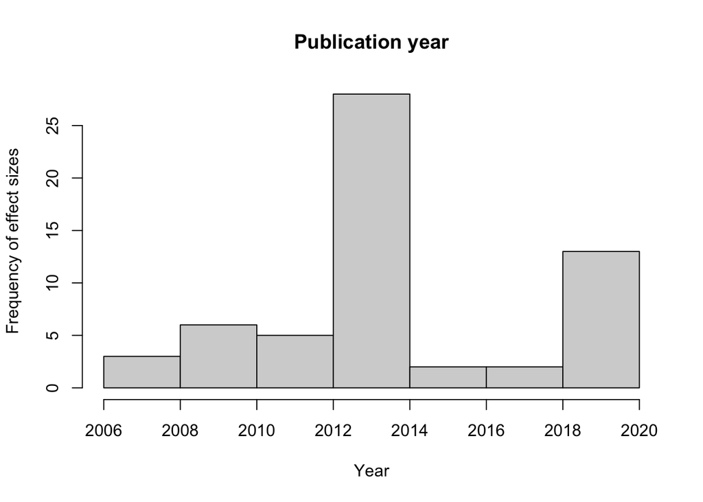

```r
# Publication year
# Effect size level
hist(dat$PubYear,
     main = "Publication year",
     xlab = "Year",
     ylab = "Frequency of effect sizes")
```

```r
median(dat$PubYear)
```

```
## [1] 2014
```

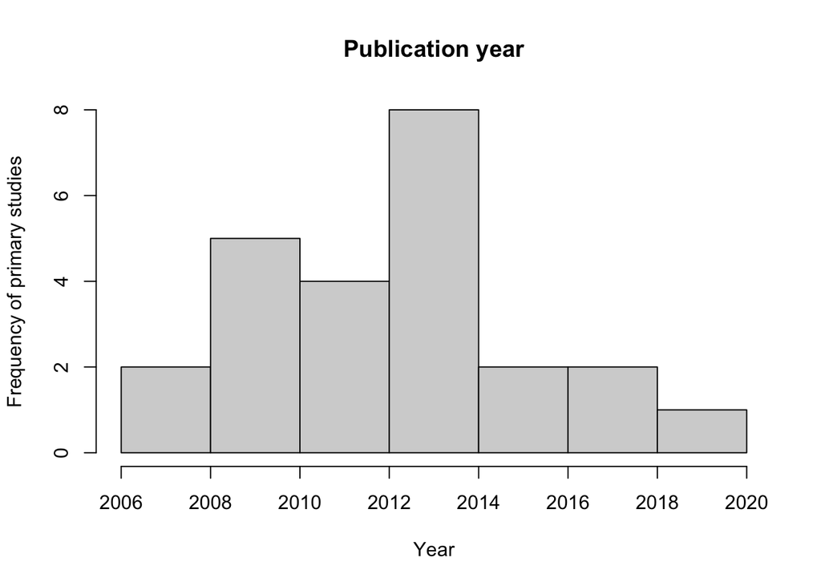

```r
# Study level
hist(aggregate(dat$PubYear, by = list(dat$IDSTUDY), FUN = mean)$x,
     main = "Publication year",
     xlab = "Year",
     ylab = "Frequency of primary studies")
```

```r
median(aggregate(dat$PubYear, by = list(dat$IDSTUDY), FUN = mean)$x)
```

```
## [1] 2013
```

```r
# IPD availability
table(dat$IPD)
```

```
##
##  0  1
## 25 34
```

```r
## Effect size level
prop.table(table(dat$IPD))*100
```

```
##
##        0        1
## 42.37288 57.62712
```

```r
## Study level
prop.table(table(aggregate(as.numeric(as.factor(dat$IPD)),
                           by = list(dat$IDSTUDY),
                           FUN = mean)$x))*100
```

```
##
##         1         2
## 91.666667  8.333333
```

# Selection of a Meta-Analytic Baseline Model

In this step, we estimate several random-effects models (REMs) under different assumptions and select a working model for subsequent reporting and analyses.

## Standard Random-Effects Model (REM)

```r
## Model estimation
REM <- rma.mv(g,
              Var.g,
              random = list(~ 1 | ESID),
              method = "REML",
              data = dat)

## Model summary
summary(REM, digits = 4)
```

```
##
## Multivariate Meta-Analysis Model (k = 59; method: REML)
##
##   logLik  Deviance       AIC       BIC      AICc
##  26.7148  -53.4296  -49.4296  -45.3088  -49.2115
##
## Variance Components:
##
##             estim    sqrt  nlvls  fixed  factor
## sigma^2    0.0156  0.1247     59     no    ESID
##
## Test for Heterogeneity:
## Q(df = 58) = 592.4533, p-val < .0001
##
## Model Results:
##
## estimate      se    zval    pval   ci.lb   ci.ub
##   0.1456  0.0178  8.1906  <.0001  0.1107  0.1804  ***
##
## ---
## Signif. codes:  0 '***' 0.001 '**' 0.01 '*' 0.05 '.' 0.1 ' ' 1
```

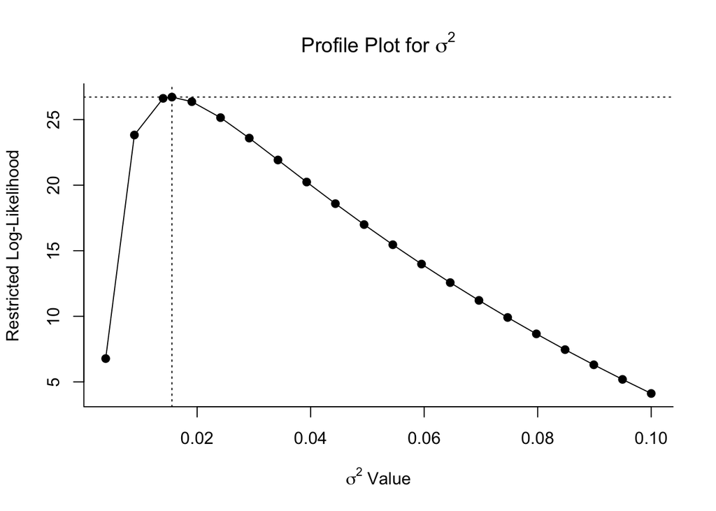

```r
## Profile plots of the variance component(s)
profile.rma.mv(REM, sigma2 = 1)
```

```r
## Robust standard errors
robust(REM, cluster = ESID, clubSandwich = TRUE)
```

```
##
## Multivariate Meta-Analysis Model (k = 59; method: REML)
##
## Variance Components:
##
##             estim    sqrt  nlvls  fixed  factor
## sigma^2    0.0156  0.1247     59     no    ESID
##
## Test for Heterogeneity:
## Q(df = 58) = 592.4533, p-val < .0001
##
## Number of estimates:   59
## Number of clusters:    59
## Estimates per cluster: 1
##
## Model Results:
##
## estimate      se¹    tval¹     df¹    pval¹   ci.lb¹   ci.ub¹
##   0.1456  0.0178   8.1973   55.02   <.0001   0.1100   0.1812   ***
##
## ---
## Signif. codes:  0 '***' 0.001 '**' 0.01 '*' 0.05 '.' 0.1 ' ' 1
##
## 1) results based on cluster-robust inference (var-cov estimator: CR2,
##    approx t-test and confidence interval, df: Satterthwaite approx)
```

```r
## Manual computation of the I-squared
## Source: https://www.metafor-project.org/doku.php/tips:i2_multilevel_multivariate

## Number of effect sizes
k <- REM$k
## Weights from the model
REM.wi <- 1/REM$vi
REM.vt <- (k-1) * sum(REM.wi) / (sum(REM.wi)^2 - sum(REM.wi^2))
100 * REM$sigma2 / (REM$sigma2 + REM.vt)
```

```
## [1] 91.72972
```

```r
## Alternative model specification
## Note: This specification provides I-squared values directly.
REM2 <- rma(g, Var.g, data = dat, method = "REML")
summary(REM2)
```

```
##
## Random-Effects Model (k = 59; tau^2 estimator: REML)
##
##   logLik  deviance       AIC       BIC      AICc
##  26.7148  -53.4296  -49.4296  -45.3088  -49.2115
##
## tau^2 (estimated amount of total heterogeneity): 0.0156 (SE = 0.0034)
## tau (square root of estimated tau^2 value):      0.1247
## I^2 (total heterogeneity / total variability):   91.73%
## H^2 (total variability / sampling variability):  12.09
##
## Test for Heterogeneity:
## Q(df = 58) = 592.4533, p-val < .0001
##
## Model Results:
##
## estimate      se    zval    pval   ci.lb   ci.ub
##   0.1456  0.0178  8.1902  <.0001  0.1107  0.1804  ***
##
## ---
## Signif. codes:  0 '***' 0.001 '**' 0.01 '*' 0.05 '.' 0.1 ' ' 1
```

```r
## Testing the hypothesis: tau2 = 0
## Variances: 95 % confidence intervals
confint(REM, digits = 4)
```

```
##
##         estimate  ci.lb  ci.ub
## sigma^2   0.0156 0.0099 0.0253
## sigma     0.1247 0.0993 0.1591
```

```r
## Model comparison: Fixed-effects model (tau2=0) vis REM
FEM <- rma.mv(g,
              Var.g,
              random = list(~ 1 | ESID),
              sigma2 = 0,  # No heterogeneity
              method = "REML",
              data = dat)

## Model summary
summary(FEM, digits = 4)
```

```
##
## Multivariate Meta-Analysis Model (k = 59; method: REML)
##
##    logLik   Deviance        AIC        BIC       AICc
## -170.9519   341.9037   343.9037   345.9642   343.9752
##
## Variance Components:
##
##             estim    sqrt  nlvls  fixed  factor
## sigma^2    0.0000  0.0000     59    yes    ESID
##
## Test for Heterogeneity:
## Q(df = 58) = 592.4533, p-val < .0001
##
## Model Results:
##
## estimate      se     zval    pval   ci.lb   ci.ub
##   0.1535  0.0049  31.6424  <.0001  0.1440  0.1630  ***
##
## ---
## Signif. codes:  0 '***' 0.001 '**' 0.01 '*' 0.05 '.' 0.1 ' ' 1
```

```r
## Model comparison: REM vs. FEM
anova(REM, FEM)
```

```
##
##         df      AIC      BIC     AICc    logLik      LRT   pval       QE
## Full     2 -49.4296 -45.3088 -49.2115   26.7148                 592.4533
## Reduced  1 343.9037 345.9642 343.9752 -170.9519 395.3334 <.0001 592.4533
```

```r
metafor::fitstats.rma(REM, FEM)
```

```
##                 REM       FEM
## logLik:    26.71482 -170.9519
## deviance: -53.42964  341.9037
## AIC:      -49.42964  343.9037
## BIC:      -45.30875  345.9642
## AICc:     -49.21146  343.9752
```

## Multilevel Random-Effects Models (ML-REM)

### Three-level REMs

The first three-level REM (labelled as `REM3a`) accounts for the nesting of effect sizes in primary studies.

```r
## Levels: Effect sizes nested in primary studies
## Model estimation
REM3a <- rma.mv(g,
                Var.g,
                random = list(~ 1 | IDSTUDY/ESID),
                method = "REML",
                data = dat,
                tdist = TRUE,
                test = "t")

## Model summary
summary(REM3a, digits = 4)
```

```
##
## Multivariate Meta-Analysis Model (k = 59; method: REML)
##
##   logLik  Deviance       AIC       BIC      AICc
##  31.6963  -63.3927  -57.3927  -51.2113  -56.9482
##
## Variance Components:
##
##             estim    sqrt  nlvls  fixed        factor
## sigma^2.1  0.0268  0.1637     24     no       IDSTUDY
## sigma^2.2  0.0073  0.0852     59     no  IDSTUDY/ESID
##
## Test for Heterogeneity:
## Q(df = 58) = 592.4533, p-val < .0001
##
## Model Results:
##
## estimate      se    tval  df    pval   ci.lb   ci.ub
##   0.1291  0.0408  3.1643  58  0.0025  0.0474  0.2108  **
##
## ---
## Signif. codes:  0 '***' 0.001 '**' 0.01 '*' 0.05 '.' 0.1 ' ' 1
```

```r
## Confidence intervals of the variance component(s)
confint.rma.mv(REM3a)
```

```
##
##           estimate  ci.lb  ci.ub
## sigma^2.1   0.0268 0.0072 0.0707
## sigma.1     0.1637 0.0851 0.2659
##
##           estimate  ci.lb  ci.ub
## sigma^2.2   0.0073 0.0041 0.0134
## sigma.2     0.0852 0.0641 0.1157
```

```r
## Cluster-robust standard errors
robust(REM3a, cluster = IDSTUDY, clubSandwich = TRUE)
```

```
##
## Multivariate Meta-Analysis Model (k = 59; method: REML)
##
## Variance Components:
##
##             estim    sqrt  nlvls  fixed        factor
## sigma^2.1  0.0268  0.1637     24     no       IDSTUDY
## sigma^2.2  0.0073  0.0852     59     no  IDSTUDY/ESID
##
## Test for Heterogeneity:
## Q(df = 58) = 592.4533, p-val < .0001
##
## Number of estimates:   59
## Number of clusters:    24
## Estimates per cluster: 1-21 (mean: 2.46, median: 1)
##
## Model Results:
##
## estimate      se¹    tval¹     df¹    pval¹   ci.lb¹   ci.ub¹
##   0.1291  0.0407   3.1762   21.22   0.0045   0.0446   0.2136   **
##
## ---
## Signif. codes:  0 '***' 0.001 '**' 0.01 '*' 0.05 '.' 0.1 ' ' 1
##
## 1) results based on cluster-robust inference (var-cov estimator: CR2,
##    approx t-test and confidence interval, df: Satterthwaite approx)
```

```
## Profiling sigma2 = 1
```

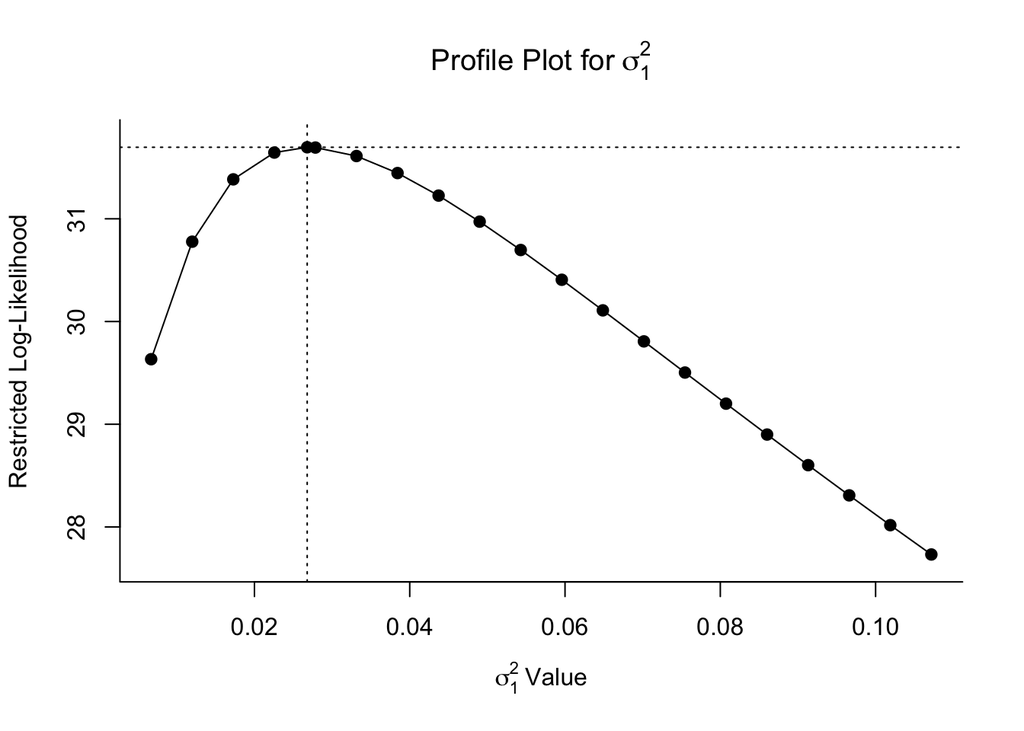

```
## Profiling sigma2 = 2
```

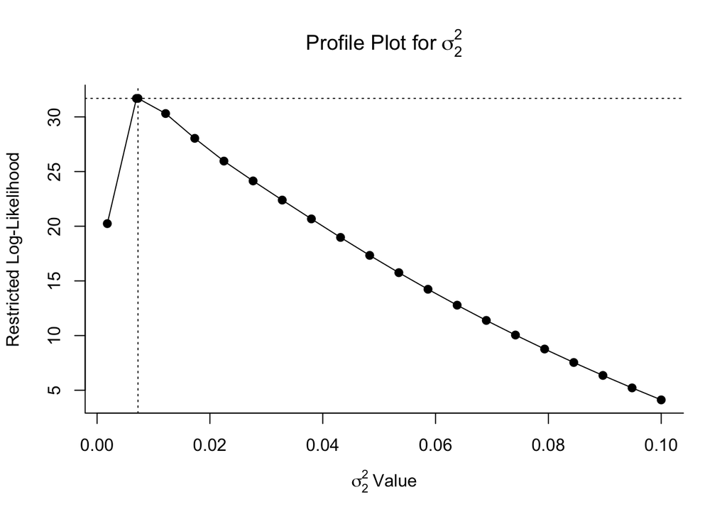

```r
## Profile plots of the variance component(s)
profile(REM3a)
```

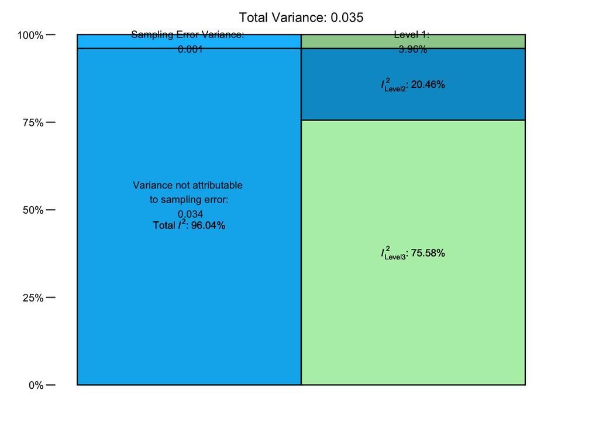

```r
## Visualization of the variance components
REM3a.var <- dmetar::var.comp(REM3a)
plot(REM3a.var)
```

```r
dmetar::mlm.variance.distribution(REM3a)
```

```
##         % of total variance    I2
## Level 1            3.956234   ---
## Level 2           20.461035 20.46
## Level 3           75.582731 75.58
## Total I2: 96.04%
```

```r
## Manual computation of the I-squared values
## Source: https://www.metafor-project.org/doku.php/tips:i2_multilevel_multivariate

REM3a.W <- diag(1/REM3a$vi)
REM3a.X <- model.matrix(REM3a)
REM3a.P <- REM3a.W - REM3a.W %*% REM3a.X %*% solve(t(REM3a.X) %*% REM3a.W %*% REM3a.X) %*% t(REM3a.X) %*% REM3a.W

## Overall I-squared
100 * sum(REM3a$sigma2) / (sum(REM3a$sigma2) + (REM3a$k-REM3a$p)/sum(diag(REM3a.P)))
```

```
## [1] 96.04377
```

```r
## Level-specific I-squared
100 * REM3a$sigma2 / (sum(REM3a$sigma2) + (REM3a$k-REM3a$p)/sum(diag(REM3a.P)))
```

```
## [1] 75.58273 20.46103
```

The second three-level REM (labelled as `REM3b`) accounts for the nesting of effect sizes in countries.

```r
## Levels: Effect sizes nested in countries
## Model estimation
REM3b <- rma.mv(g,
                Var.g,
                random = list(~ 1 | IDCOUNTRY/ESID),
                method = "REML",
                data = dat,
                tdist = TRUE,
                test = "t")

## Model summary
summary(REM3b, digits = 4)
```

```
##
## Multivariate Meta-Analysis Model (k = 59; method: REML)
##
##   logLik  Deviance       AIC       BIC      AICc
##  26.7718  -53.5436  -47.5436  -41.3623  -47.0992
##
## Variance Components:
##
##             estim    sqrt  nlvls  fixed          factor
## sigma^2.1  0.0009  0.0297     31     no       IDCOUNTRY
## sigma^2.2  0.0144  0.1199     59     no  IDCOUNTRY/ESID
##
## Test for Heterogeneity:
## Q(df = 58) = 592.4533, p-val < .0001
##
## Model Results:
##
## estimate      se    tval  df    pval   ci.lb   ci.ub
##   0.1457  0.0184  7.9075  58  <.0001  0.1088  0.1826  ***
##
## ---
## Signif. codes:  0 '***' 0.001 '**' 0.01 '*' 0.05 '.' 0.1 ' ' 1
```

```r
## Confidence intervals of the variance component(s)
confint.rma.mv(REM3b)
```

```
##
##           estimate  ci.lb  ci.ub
## sigma^2.1   0.0009 0.0000 0.0088
## sigma.1     0.0297 0.0000 0.0940
##
##           estimate  ci.lb  ci.ub
## sigma^2.2   0.0144 0.0068 0.0251
## sigma.2     0.1199 0.0824 0.1586
```

```r
## Cluster-robust standard errors
robust(REM3b, cluster = IDCOUNTRY, clubSandwich = FALSE)
```

```
##
## Multivariate Meta-Analysis Model (k = 59; method: REML)
##
## Variance Components:
##
##             estim    sqrt  nlvls  fixed          factor
## sigma^2.1  0.0009  0.0297     31     no       IDCOUNTRY
## sigma^2.2  0.0144  0.1199     59     no  IDCOUNTRY/ESID
##
## Test for Heterogeneity:
## Q(df = 58) = 592.4533, p-val < .0001
##
## Number of estimates:   59
## Number of clusters:    31
## Estimates per cluster: 1-7 (mean: 1.90, median: 1)
##
## Model Results:
##
## estimate      se¹    tval¹  df¹    pval¹   ci.lb¹   ci.ub¹
##   0.1457  0.0183   7.9725   30   <.0001   0.1084   0.1831   ***
##
## ---
## Signif. codes:  0 '***' 0.001 '**' 0.01 '*' 0.05 '.' 0.1 ' ' 1
##
## 1) results based on cluster-robust inference (var-cov estimator: CR1,
##    approx t-test and confidence interval, df: residual method)
```

```
## Profiling sigma2 = 1
```

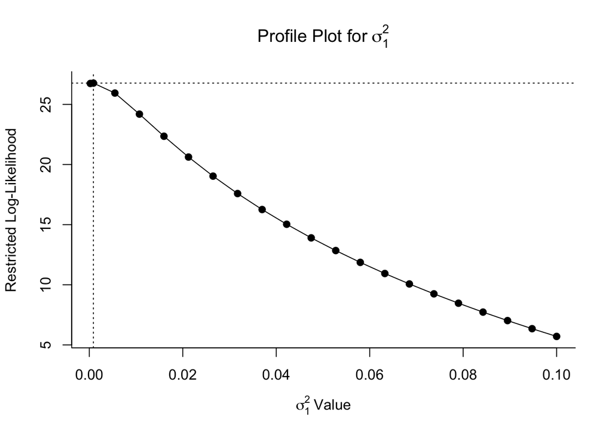

```
## Profiling sigma2 = 2
```

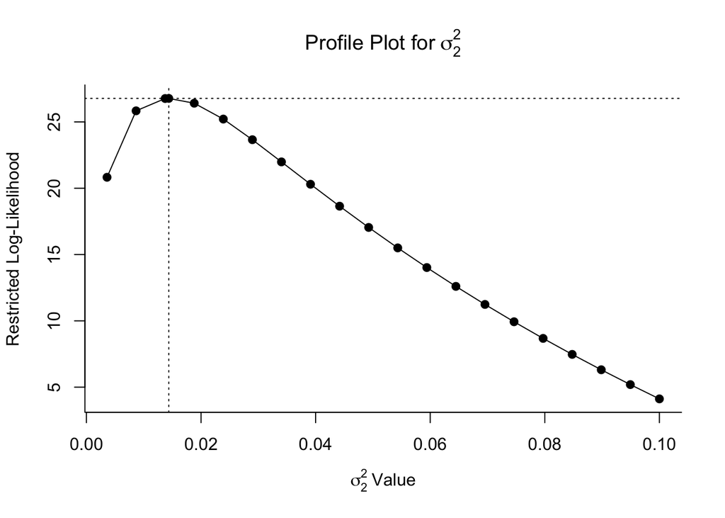

```r
## Profile plots of the variance component(s)
profile(REM3b)
```

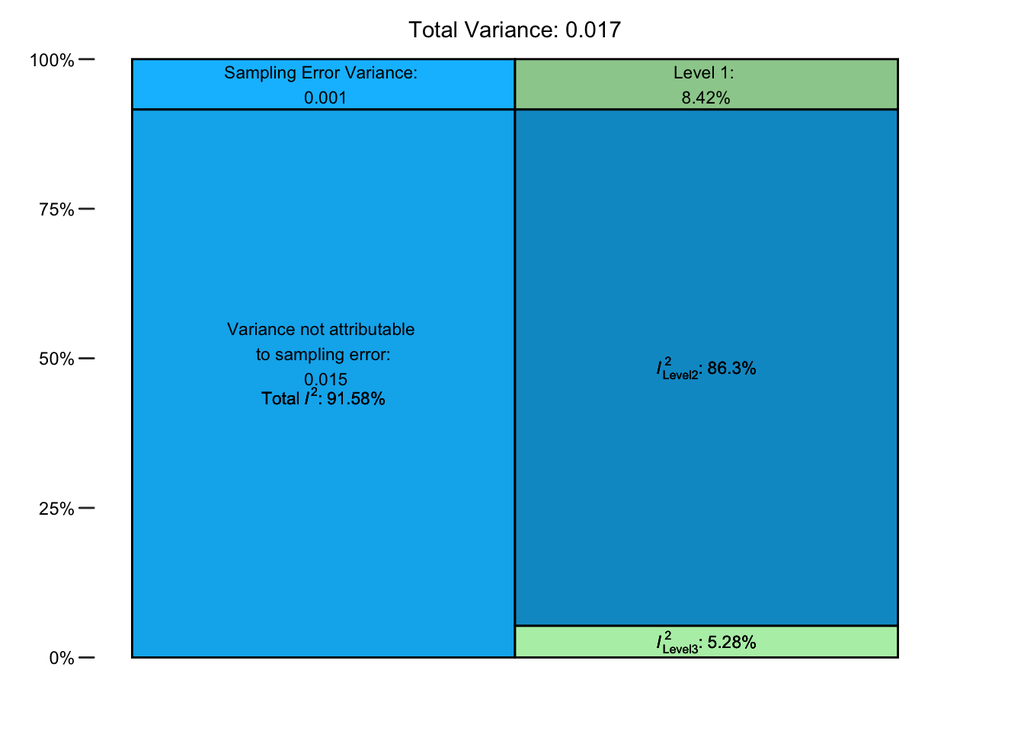

```r
## Visualization of the variance components
REM3b.var <- dmetar::var.comp(REM3b)
plot(REM3b.var)
```

```r
dmetar::mlm.variance.distribution(REM3b)
```

```
##         % of total variance   I2
## Level 1            8.420512  ---
## Level 2           86.300279 86.3
## Level 3            5.279209 5.28
## Total I2: 91.58%
```

```r
## Manual computation of the I-squared values
## Source: https://www.metafor-project.org/doku.php/tips:i2_multilevel_multivariate
REM3b.W <- diag(1/REM3b$vi)
REM3b.X <- model.matrix(REM3b)
REM3b.P <- REM3b.W - REM3b.W %*% REM3b.X %*% solve(t(REM3b.X) %*% REM3b.W %*% REM3b.X) %*% t(REM3b.X) %*% REM3b.W

## Overall I-squared
100 * sum(REM3b$sigma2) / (sum(REM3b$sigma2) + (REM3b$k-REM3b$p)/sum(diag(REM3b.P)))
```

```
## [1] 91.57949
```

```r
## Level-specific I-squared
100 * REM3b$sigma2 / (sum(REM3b$sigma2) + (REM3b$k-REM3b$p)/sum(diag(REM3b.P)))
```

```
## [1]  5.279209 86.300279
```

### Cross-classified REMs

In this cross-classified model, the independent nesting of effect sizes in primary studies and countries is modeled.

```r
## Model estimation
CCREM <- rma.mv(g,
                Var.g,
                random = list(~ 1 | IDSTUDY/ESID,
                              ~ 1 | IDCOUNTRY),
                method = "REML",
                data = dat,
                tdist = TRUE,
                test = "t",
                time = TRUE)
```

```
##
## Processing time: 0 hours, 0 minutes, 0.06 seconds
```

```r
## Model summary
summary(CCREM, digits = 4)
```

```
##
## Multivariate Meta-Analysis Model (k = 59; method: REML)
##
##   logLik  Deviance       AIC       BIC      AICc
##  33.8044  -67.6088  -59.6088  -51.3670  -58.8541
##
## Variance Components:
##
##             estim    sqrt  nlvls  fixed        factor
## sigma^2.1  0.0308  0.1754     24     no       IDSTUDY
## sigma^2.2  0.0016  0.0397     59     no  IDSTUDY/ESID
## sigma^2.3  0.0055  0.0743     31     no     IDCOUNTRY
##
## Test for Heterogeneity:
## Q(df = 58) = 592.4533, p-val < .0001
##
## Model Results:
##
## estimate      se    tval  df    pval   ci.lb   ci.ub
##   0.0951  0.0444  2.1424  58  0.0364  0.0062  0.1839  *
##
## ---
## Signif. codes:  0 '***' 0.001 '**' 0.01 '*' 0.05 '.' 0.1 ' ' 1
```

```r
## Confidence intervals of the variance component(s)
confint.rma.mv(CCREM)
```

```
##
##           estimate  ci.lb  ci.ub
## sigma^2.1   0.0308 0.0112 0.0770
## sigma.1     0.1754 0.1057 0.2775
##
##           estimate  ci.lb  ci.ub
## sigma^2.2   0.0016 0.0000 0.0079
## sigma.2     0.0397 0.0000 0.0886
##
##           estimate  ci.lb  ci.ub
## sigma^2.3   0.0055 0.0003 0.0122
## sigma.3     0.0743 0.0175 0.1105
```

```r
## Cluster-robust standard errors
robust(CCREM, cluster = IDSTUDY, clubSandwich = FALSE)
```

```
##
## Multivariate Meta-Analysis Model (k = 59; method: REML)
##
## Variance Components:
##
##             estim    sqrt  nlvls  fixed        factor
## sigma^2.1  0.0308  0.1754     24     no       IDSTUDY
## sigma^2.2  0.0016  0.0397     59     no  IDSTUDY/ESID
## sigma^2.3  0.0055  0.0743     31     no     IDCOUNTRY
##
## Test for Heterogeneity:
## Q(df = 58) = 592.4533, p-val < .0001
##
## Number of estimates:   59
## Number of clusters:    24
## Estimates per cluster: 1-21 (mean: 2.46, median: 1)
##
## Model Results:
##
## estimate      se¹    tval¹  df¹    pval¹    ci.lb¹   ci.ub¹
##   0.0951  0.0474   2.0034   23   0.0571   -0.0031   0.1932   .
##
## ---
## Signif. codes:  0 '***' 0.001 '**' 0.01 '*' 0.05 '.' 0.1 ' ' 1
##
## 1) results based on cluster-robust inference (var-cov estimator: CR1,
##    approx t-test and confidence interval, df: residual method)
```

```r
robust(CCREM, cluster = IDCOUNTRY, clubSandwich = FALSE)
```

```
##
## Multivariate Meta-Analysis Model (k = 59; method: REML)
##
## Variance Components:
##
##             estim    sqrt  nlvls  fixed        factor
## sigma^2.1  0.0308  0.1754     24     no       IDSTUDY
## sigma^2.2  0.0016  0.0397     59     no  IDSTUDY/ESID
## sigma^2.3  0.0055  0.0743     31     no     IDCOUNTRY
##
## Test for Heterogeneity:
## Q(df = 58) = 592.4533, p-val < .0001
##
## Number of estimates:   59
## Number of clusters:    31
## Estimates per cluster: 1-7 (mean: 1.90, median: 1)
##
## Model Results:
##
## estimate      se¹    tval¹  df¹    pval¹   ci.lb¹   ci.ub¹
##   0.0951  0.0330   2.8818   30   0.0072   0.0277   0.1624   **
##
## ---
## Signif. codes:  0 '***' 0.001 '**' 0.01 '*' 0.05 '.' 0.1 ' ' 1
##
## 1) results based on cluster-robust inference (var-cov estimator: CR1,
##    approx t-test and confidence interval, df: residual method)
```

```
## Profiling sigma2 = 1
```

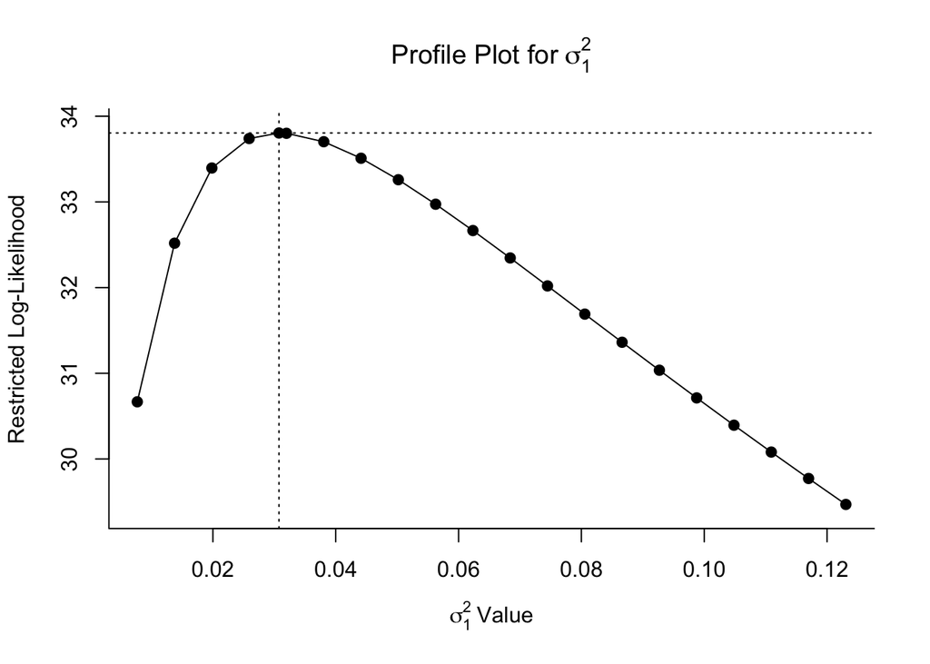

```
## Profiling sigma2 = 2
```

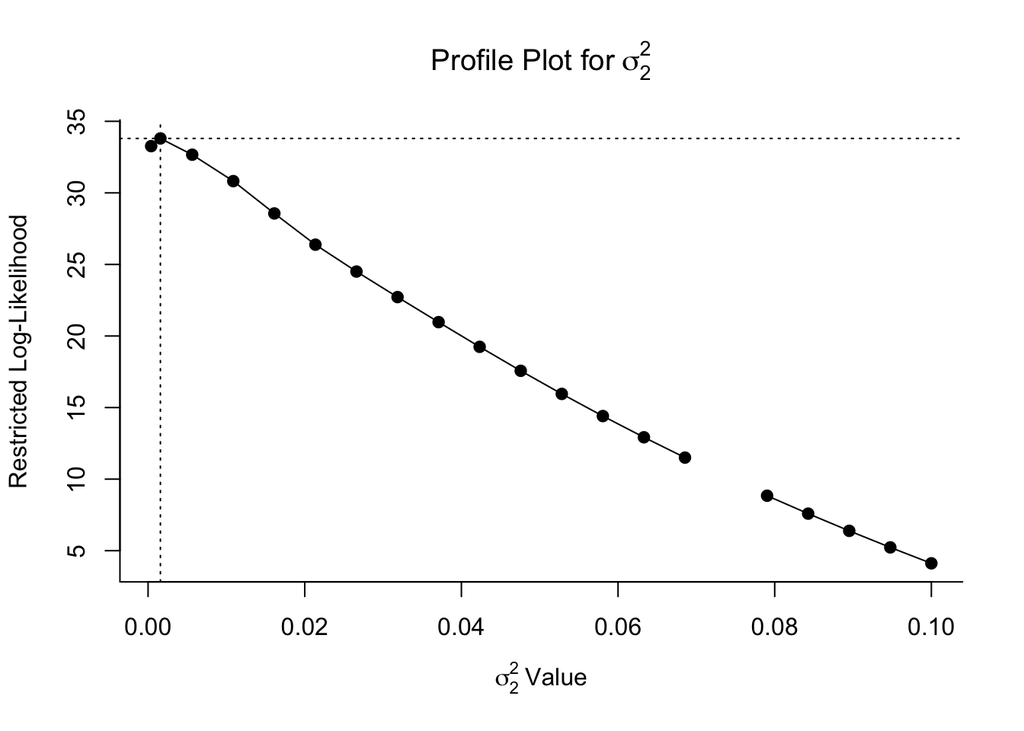

```
## Profiling sigma2 = 3
```

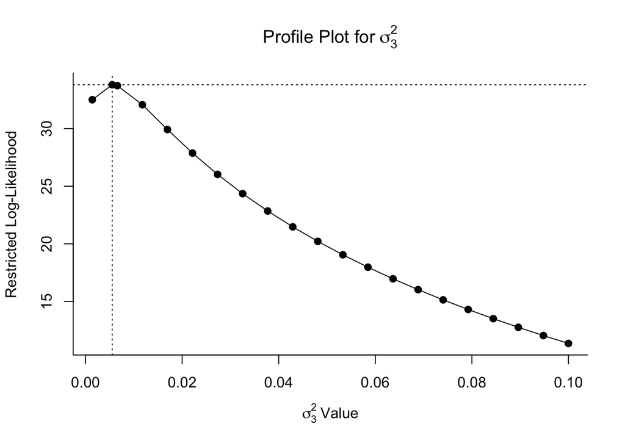

```r
## Profile plots of the variance component(s)
profile(CCREM)
```

```r
## Manual computation of the I-squared values
CCREM.W <- diag(1/CCREM$vi)
CCREM.X <- model.matrix(CCREM)
CCREM.P <- CCREM.W - CCREM.W %*% CCREM.X %*% solve(t(CCREM.X) %*% CCREM.W %*% CCREM.X) %*% t(CCREM.X) %*% CCREM.W

## Overall I-squared
100 * sum(CCREM$sigma2) / (sum(CCREM$sigma2) + (CCREM$k-CCREM$p)/sum(diag(CCREM.P)))
```

```
## [1] 96.42712
```

```r
## Level-specific I-squared
100 * CCREM$sigma2 / (sum(CCREM$sigma2) + (CCREM$k-CCREM$p)/sum(diag(CCREM.P)))
```

```
## [1] 78.371363  4.008578 14.047175
```

[figure not shown]

```r
## Forest plot (with extra annotations)
dd <- c(0,diff(dat$IDSTUDY))
dd[dd > 0] <- 1
rows <- (1:CCREM$k) + cumsum(dd)
op <- par(tck=-0.01, mgp = c(1.6,0.2,0), mar=c(3,8,1,6))
forest(CCREM,
       slab=dat$Reference,
       header="Author(s) and Year",
       mlab="",
       shade=TRUE,
       cex = 0.65,
       xlab="Standardized Mean Difference (SMD, Hedges' g)",
       rows=rows, ylim=c(0.5,max(rows)+3))
abline(h = rows[c(1,diff(rows)) == 2] - 1, lty="dotted")
par(op)

# Assuming you have already created the forest plot
text(x = -2.5,
     y = 0,
     labels = expression(paste("CCREM Model (", I^2, " = 96.4%)")),
     pos = 1,
     cex = 0.60,
     font = 2)
```